# Exploratory Data Analysis

Hakan Egeli

Soumyendu Sarkar

May 8, 2018

# Exploratory Data Analysis.

## Sales Attributes and Possible Correlations

### Correlation of Sales Summaries and Credit Limit

Since our Naive model was based on **Sales Last Year**, we wanted to see how all the sales summary variables correlated to the **Credit Limit**

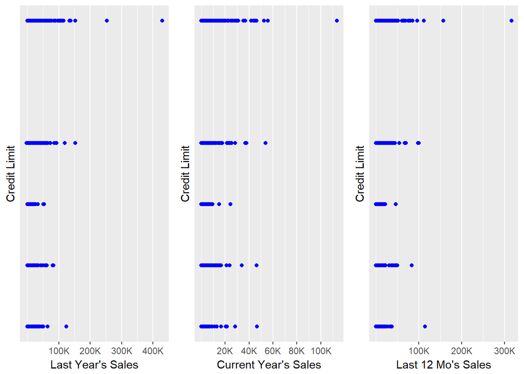

Unfortunately, we did not see a linear correlation between any of the Sales summary variables and the Credit Limit.

### Correlation of 12 Months Sales and Major Product Category Sales

Since the major product category sales for the last 12 months make up majority of the **Last 12 Mo Sales Total** we wanted to examine which product(s) had the most significant correlation.

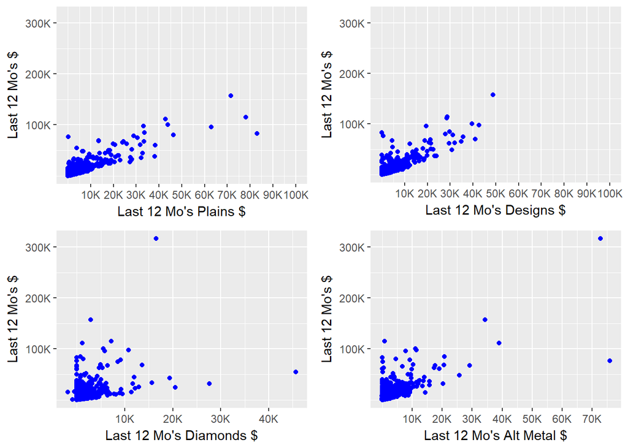

From the scatter plots above, we can see that Plain Bands and Design Bands seem to have the strongest correlation and Diamond Bands and the Alternative Metal Bands have the least.

### Distribution of Credit Limit

We also wanted to understand how the **Credit Limits** were distributed and if the distribution was Gaussian. After plotting a histogram we realized that the Credit Limit distribution was not Gaussian.

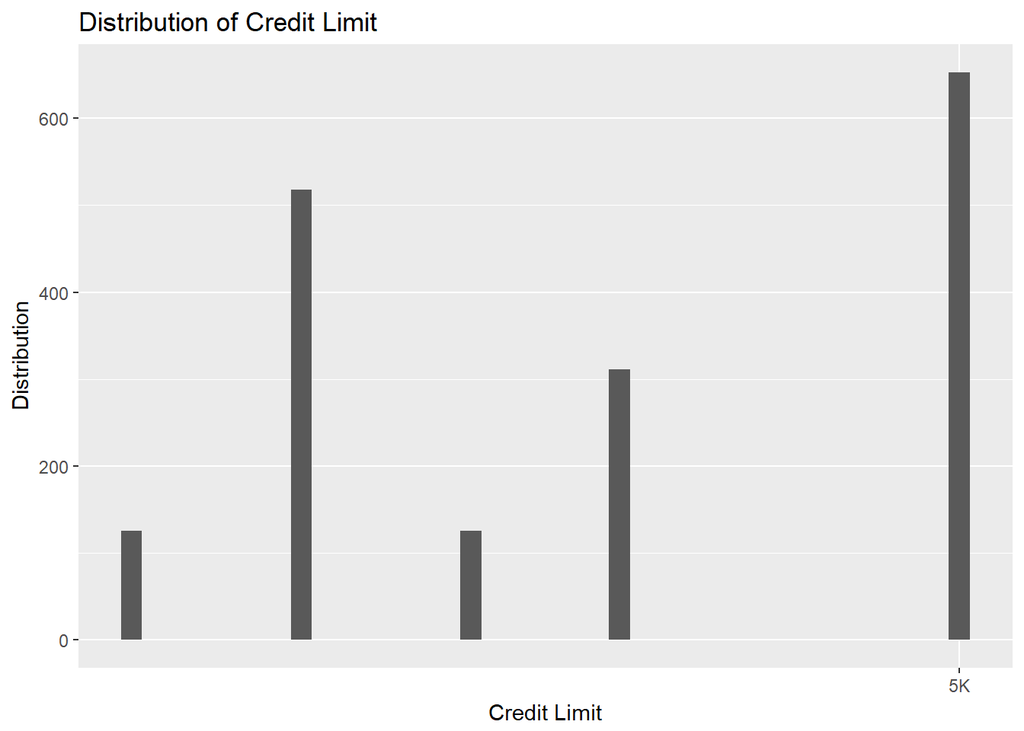

### Relationship Between Avg Days of Pay and Credit Limits

Then we wanted to examine if there was a realtionship between the **Average Days of Pay Categories** and the **Credit Limit**.

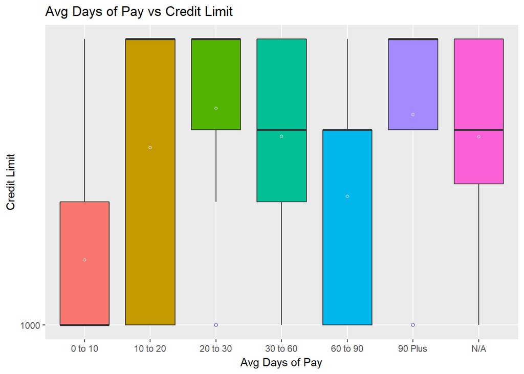

If we remove the Category N/A from the plot, we do see that the means (white circles) do show a possible polynomial relationship. We also wanted to see what the distribution of **Credit Limits** looked like for each of the **Average Days of Pay**.

### Distribution of Credit Limit Among Avg Days of Pay

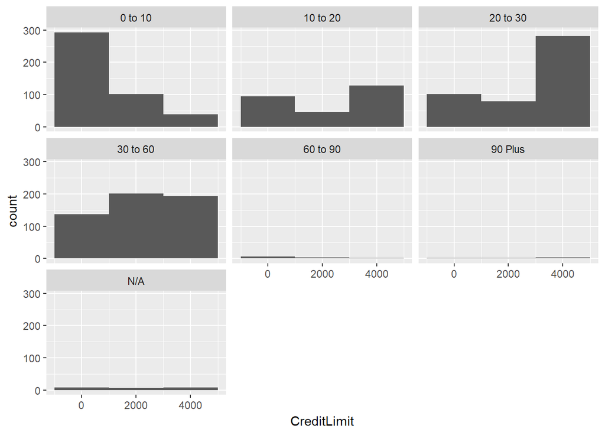

We have examined our dataset for near zero variance parameters and identified the following variables to be near zero:

```
##                       freqRatio percentUnique zeroVar  nzv
## ReturnedPaymentCount   122.4286     0.2886836   FALSE TRUE
## MaxReturnedPaymentAmt 1714.0000     1.0969977   FALSE TRUE
## NA                           NA            NA      NA   NA
## NA.1                         NA            NA      NA   NA
## NA.2                         NA            NA      NA   NA
```

We have observed that the near zero variance parameters were returns related and We did not further investigate the remaining Returns related variables in our dataset.

## Non-Sales Attributes and Possible Correlations

We enhanced our dataset by bringing in Census data for **Retail Trade: Geographic Area Series: Summary Statistics for the U.S., States, Metro Areas, Counties, and Places**, **Annual Estimates of the Resident Population**, **MEDIAN INCOME IN THE PAST 12 MONTHS (IN 2016 INFLATION-ADJUSTED DOLLARS)**, **TOTAL POPULATION**, and **INDUSTRY BY MEDIAN EARNINGS IN THE PAST 12 MONTHS (IN 2016 INFLATION-ADJUSTED DOLLARS) FOR THE CIVILIAN EMPLOYED POPULATION 16 YEARS AND OVER** and mapped these values to our customer records via StateFIPS, CountyFIPS and CBSA Codes (for metro areas).

### Avg Days of Pay and Median Household Income

We wanted to see if there was a correlation between the Average Days of Pay and Median Household Income where the stores are located and we did see that the first three categories had very similar patterns of Median Income distribution.

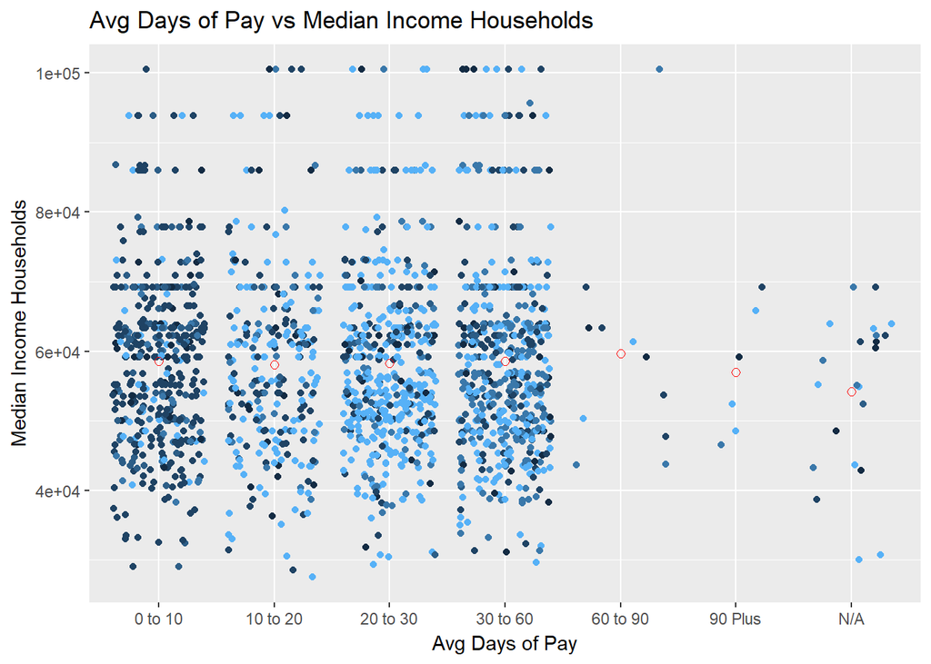

And finally we wanted to examine if there was any kind of correlation between the ** Total Sales Last 12 Mos** and the **Urban Influence**. Urban Influence is an indicator which describes a statistical area whether it is a Major Metro Area, Micro Metro Area, Micro Metro Adjesent to a Major Metro Area, or more Rural.

Additionally, we have examined the correlation between the **Total Population** and the **Number of Jewelry Stores** (via the NAICS Code 4483 - Jewelry Stores) associated with that customer’s location.

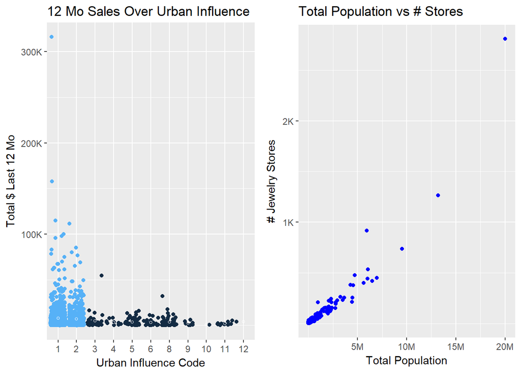

We did see that the larger Metro and Micro areas (light blue, Urban Influence Codes 1 and 2) did have customers with higher **Total SalesLast 12 Mos** and as the **Urban Influence** moved towards rural the total sales significantly became lower. Additionally, we saw a significant correlation between the **Total Population** and the **Number of Stores** from out dataset.